# Shut the Box

Martin

May 9, 2016

I want to know how likely it is to win a game of “Shut the Box” by closing all numbers. In particular, I’m interested about what happens when the box goes all the way up to 12.

Given that the box has twelve numbers, and that we can roll only one die when the sum of the numbers left in the box is less than 6, what is the probability of shutting the box completely?

I wrote a [python script](https://github.com/mbontrager/shut_the_box/blob/master/shut_the_box.py) that simulates playing a round of Shut the Box, and ran it 1 million times to find the chance of closing the box (scoring 0).

### Short answer: You can shut the box ~ 0.41% of the time, or about 1 in 250 tries

```r
library(ggplot2)
theme_set(theme_bw(base_size = 20))
#setwd("Projects/shut_the_box")
a <- read.csv("box_scores.csv", header = FALSE)

p <- ggplot(a, aes(x=V1)) + geom_histogram(color="black", fill="white", binwidth = 1) +
    xlab("Score") + ylab("Count") +
    geom_vline(aes(xintercept=mean(V1)), color="red", linetype="dashed", size=1) +
    annotate("Text", x = 60, y = 33000, label = paste("Mean = ", round(mean(a$V1), 1)), size = 10)
```

Here is a histogram of 1 million simulated rounds of playing Shut the Box. The average score (the red dashed line) is around 36:

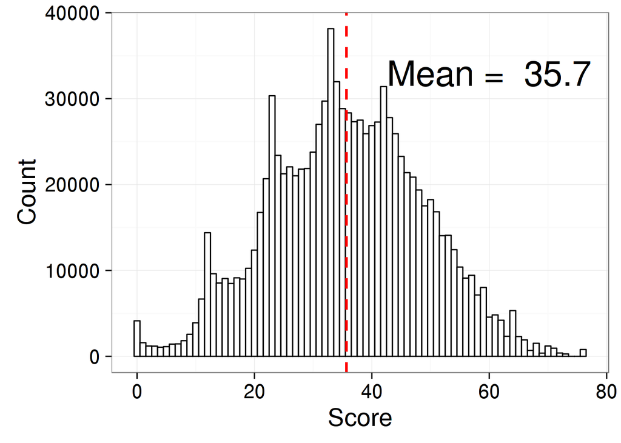

That’s cool. It’s also kind of interesting that there peaks where some scores are more likely than others.

Even though the average score was around 36, the most common score in Shut the Box is a 33. At least in the way that I’m telling the computer to close numbers.

```r
library(dplyr); library(knitr); library(data.table); library(scales)
Percent <- sort(summary(as.factor(a$V1)), decreasing = TRUE)
df <- as.data.frame(Percent)
setDT(df, keep.rownames=TRUE)
df$percent <- transmute(df, Percent = percent(Percent / sum(Percent)))
x <- percent((df[rn %in% c(1:12),][, sum(Percent)]) / df[,sum(Percent)])
df <- df[, .(rn, percent)]
colnames(df) <- c("Score", "Percent")
```

The following table is a breakdown of the most common scores by percent that they showed up in 1 million simulations. I think one of the most interesting things is that shutting the box (scoring 0) is not the least likely outcome. According to the following table, it’s more rare that you’d end up with an end score of 9, for example. Some of that has to do with how the computer makes the decisions. But it’s also pretty common that you would roll a 5-9, and if not they can be used to close other numbers, so it’s rare that you would end up with, say, a 9 being the only number left.

| Score | Percent |
| --- | --- |
| 33 | 3.82% |
| 34 | 3.20% |
| 42 | 3.14% |
| 23 | 3.04% |
| 32 | 2.97% |
| 35 | 2.89% |
| 36 | 2.84% |
| 43 | 2.78% |
| 38 | 2.75% |
| 37 | 2.73% |
| 41 | 2.73% |
| 31 | 2.70% |
| 40 | 2.69% |
| 39 | 2.59% |
| 44 | 2.59% |
| 30 | 2.38% |
| 24 | 2.34% |
| 45 | 2.33% |
| 26 | 2.21% |
| 29 | 2.19% |
| 28 | 2.18% |
| 46 | 2.14% |
| 25 | 2.13% |
| 27 | 2.10% |
| 47 | 2.09% |
| 22 | 2.07% |
| 48 | 1.94% |
| 50 | 1.82% |
| 49 | 1.75% |
| 51 | 1.68% |
| 21 | 1.68% |
| 12 | 1.44% |
| 53 | 1.41% |
| 52 | 1.40% |
| 54 | 1.24% |
| 20 | 1.24% |
| 55 | 1.04% |
| 19 | 1.02% |
| 13 | 0.96% |
| 57 | 0.94% |
| 17 | 0.91% |
| 56 | 0.91% |
| 15 | 0.91% |
| 18 | 0.90% |
| 14 | 0.85% |
| 16 | 0.85% |
| 59 | 0.80% |
| 58 | 0.71% |
| 11 | 0.67% |
| 64 | 0.53% |
| 61 | 0.48% |
| 60 | 0.46% |
| 62 | 0.42% |
| 0 | 0.41% |
| 10 | 0.39% |
| 9 | 0.26% |
| 63 | 0.23% |
| 65 | 0.23% |
| 66 | 0.19% |
| 8 | 0.18% |
| 1 | 0.16% |
| 68 | 0.15% |
| 7 | 0.14% |
| 6 | 0.14% |
| 70 | 0.12% |
| 2 | 0.12% |
| 3 | 0.12% |
| 5 | 0.11% |
| 4 | 0.11% |
| 71 | 0.09% |
| 76 | 0.08% |
| 67 | 0.07% |
| 72 | 0.04% |
| 69 | 0.04% |
| 73 | 0.03% |